# Probando con R

## Instalar librerías

Las librerías permiten ampliar la funcionalidad de R. Para instalar las librerías de forma normal debemos utilizar el siguiente código...

```r
install.packages ("ggplot2")
```

```
Error in install.packages("ggplot2"): unable to install packages
Traceback:

1. install.packages("ggplot2")
2. stop("unable to install packages")
```

En clase, hubo un error. No conseguimos instalar la librería de esta forma.

## Importar librerías

Para importar librerías utilizamos ggplot, función que permite especificar los datos. Este sistema crea gráficos de forma declarativa, basándose en la gramática de los datos. Si añadimos ciertos datos, nos permite asignar una estética a las variables elegidas, pues la función ggplot se ocupa de los detalles.

```r
library(ggplot2)
```

## Create Dataset

Para ello lo que hacemos es seleccionar los datos que queremos que sean representados. A partir de un ggplot ya creado y ofrecido por el profesor, sacamos las aeronaves, artillería y tanques. Con la instrucción rep(x,r) se genera una lista de r valores todos iguales a x. Con la instrucción abs escogemos el valor absoluto de ciertos números (para llegar al value). Para crear un data frame usamos la función data.frame(). Esta función nos pedirá un número de vectores igual al número de columnas que deseemos. Todos los vectores que proporcionemos deben tener el mismo largo.

```r
# create a dataset
bajas <- c(rep("Tanques" , 2) , rep("Artillería" , 2) , rep("Aeronaves" , 2) )
paises <- rep(c("Rusia" , "Ucrania") , 3)
value <- abs(rnorm(12 , 0 , 15))
data <- data.frame(bajas,paises,value)
```

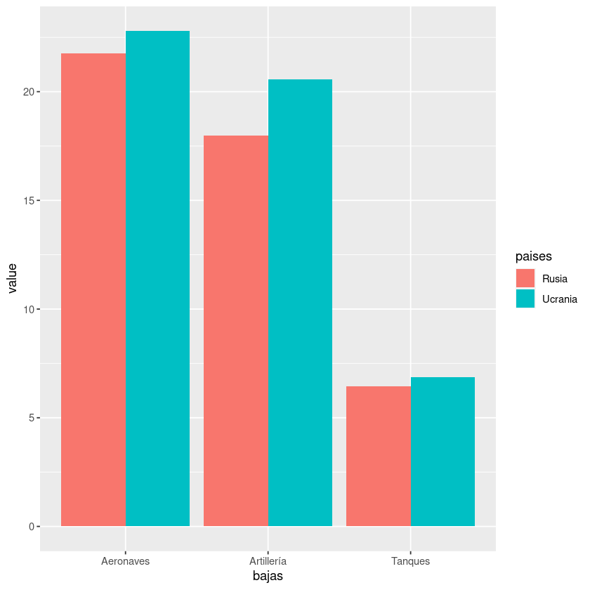

```r
# Grouped
ggplot(data, aes(fill=paises, y=value, x=bajas)) +
    geom_bar(position="dodge", stat="identity")
```

En clase observamos que a cada persona le aparecía el gráfico de una manera diferente.

En este último apartado surgen dudas acerca de cómo se obtienen los datos y por qué son distintos.